# Porównie NSE

Piotr Janus

15 11 2019

# 1 Zbiory wykorzystane podczas testowania

Każdy z nich posiada 10 kolumn, a także dla małego, średniego, dużego kolejno $10$, $10^3$, $10^5$ wierszy.

```r
set.seed(2137)
sample_df_big <- runif(1e6) %>%  matrix(ncol = 10) %>% data.frame()

sample_df_medium <- runif(1e4) %>%  matrix(ncol = 10) %>% data.frame()

sample_df_smol <- runif(1e2) %>%  matrix(ncol = 10) %>% data.frame()
```

# 2 Wersje funkcji NSE

```r
zadanieDomowe1 <- function(func){
  function(data_s, arg=NA, ...) {
    expre <- quote(func(data_s, ...))
    if(!missing(arg)) {
      if(is_formula(substitute(arg)))
      {
        expre <- quote(func(data_s, formula = arg, ...))
      }
      else {
        data_s <- eval(substitute(arg), data_s)
        expre <- quote(func(data_s, ...))
      }
    }
    eval(expre)
  }
}

zadanieDomowe2 <- function(func){
  function(data_s, arg=NA, ...) {
    expre <- rlang::expr(func(data_s, !!!list(...)))
    if(!missing(arg)) {
      if(is_formula(enexpr(arg)))
      {
        expre <- rlang::expr(func(data_s, formula = arg, !!!list(...)))
      }
      else {
        data_s <- eval(enexpr(arg), data_s)
        expre <- rlang::expr(func(data_s, !!!list(...)))
      }
    }
    rlang::eval_tidy(expre, caller_env())
  }
}

zadanieDomowe3 <- function(func) {
  function(data, arg, ...) {
    args <- match.call(expand.dots = FALSE)$`...`
    if(!missing(arg)) {
      data <- eval(substitute(arg), data)
    }
    do.call(func, list(data, ...))
  }
}

zadanieDomowe4 <- function(func) {
  function(data, arg, ...) {
    args <- match.call(expand.dots = FALSE)$`...`
    if(!missing(arg)) {
      data <- eval(substitute(arg), data)
    }
    rlang::invoke(func, list(data, ...))
  }
}
```

# 3 Funkcja `min`

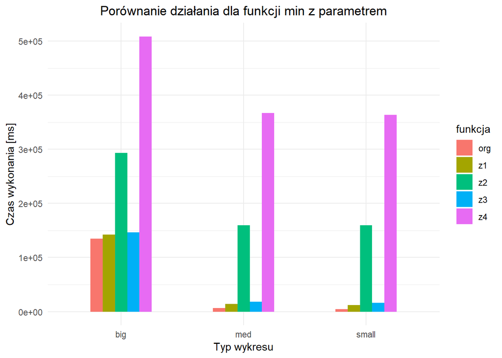

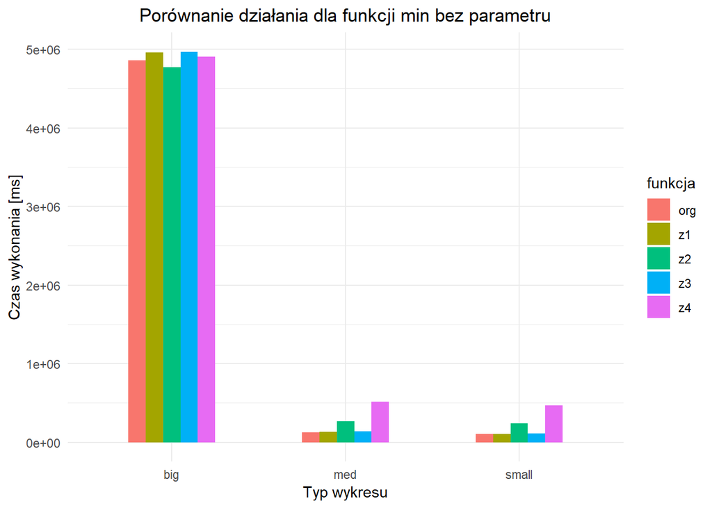

# 4 Funkcja `mean`

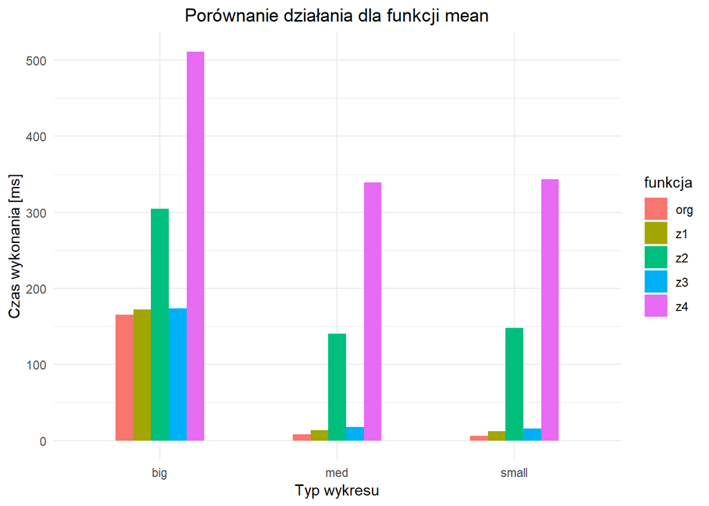

# 5 Funkcja `unlist`

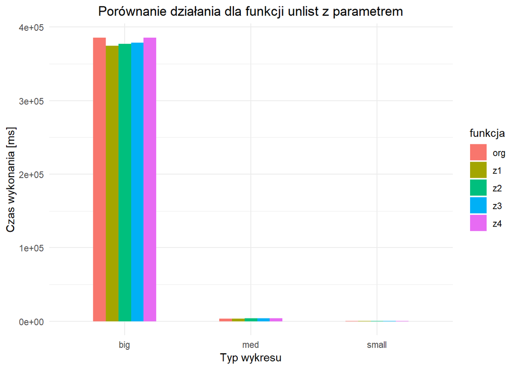

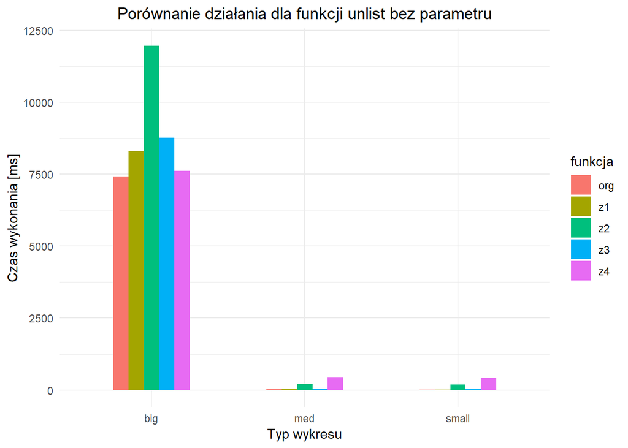

# 6 Funkcja `lm`

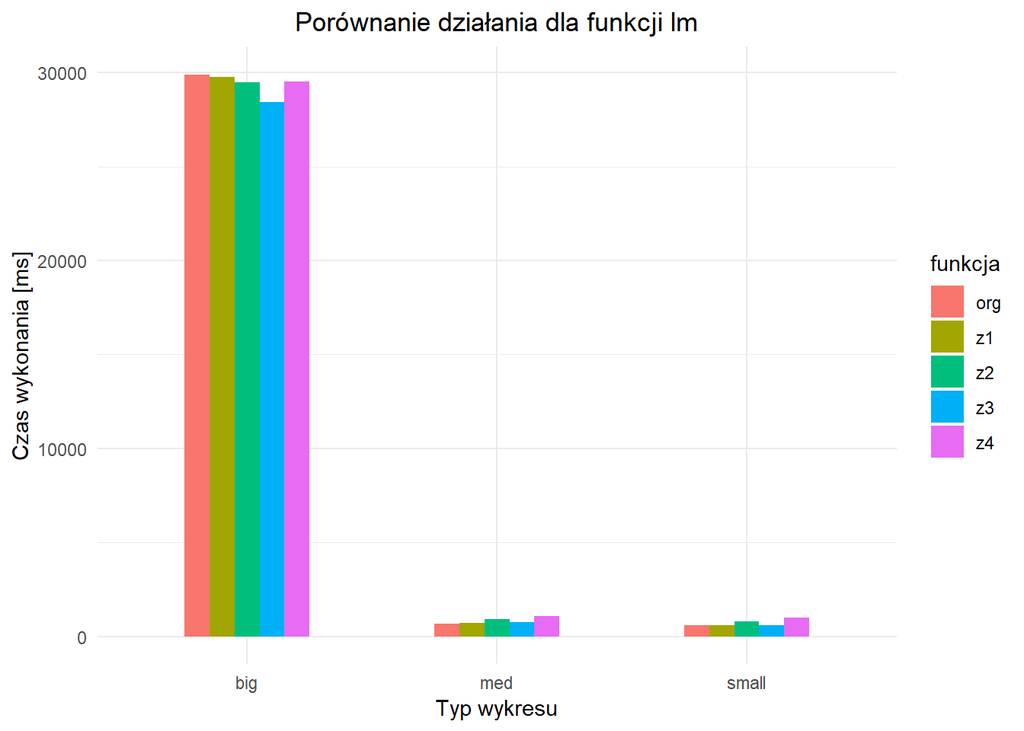

# 7 Podsumowanie

- Funkcje nieskalane moją implementacją NSE z reguły działają szybciej dla zbioru małego i średniego.
- Sytuacja się nieco odwraca dla scenariusza, gdy na tapete bierzemy zbiór duży. Nadal czas wykonania pozostaje jedym z najmniejszych, jednak są sytuacje kiedy lepiej sprawuje się funkcja NSE.
- Dla małych zbiorów i niemal każdej funkcji z testowanych najgorzej sprawuje się wersja NSE z `invoke`, które w dokumentacji opisane jest następująco “invoke() is basically a version of base::do.call()”. Dla dużych zbiorów, narzut związany ze stworzeniem środowiska, wypłaca nam benefity w postaci krótszego czasu wykonania dla niektórych funkcji.
- Podobnie ma sie korzystanie z `rlang::expr` oraz `rlang:eval_tidy`, które dla małych zbiorów generalnie wypadają gorzej… Dla dużych też, ale to nie jest już reguła.
- Generalnie `do.call` działa lepiej dla mały zbiorów niż `invoke`.
- Funkcje `org`, `z1`, `z3`, po lekkim zmrużeniu oczu, działają mniej więcej tak samo, niezależnie od wielkości zbioru.
- Różnica między zbiorem $10$ a $10^3$ jest mała, natomiast między $10^5$, a resztą jest już bardzo duża.